# Human Perception of Statistical Charts: An Introduction to Graphical Testing Methods

Washington State University

Emily Robinson

Cal Poly - San Luis Obispo

Reka Howard

University of Nebraska - Lincoln

Susan VanderPlas

Utah State University

2026-10-21

## Outline

Motivation and Background

Comprehensive Graphical Testing

Research Goals

Perception through Lineups

Prediction through ‘You Draw It’

Numerical Translation and Estimation

Overall Conclusions and Discussion

Recent Work and Directions

## Introduction to Graphics

Data visualization is defined as the art of drawing graphical charts in order to display data Unwin (2020).

**What are graphics useful for?** Lewandowsky and Spence (1989)

📉 Data cleaning.

🔎 Exploring data structure.

💬 Communicating information.

**Who uses graphics?**

- Governments (Harms 1991; Playfair 1801; Walker 2013).
- Companies (Chandar et al. 2012; Yates 1985).
- News sources and mass media (Aisch et al. 2016).
- Scientific publications (Gouretski and Koltermann 2007).

## History of Graphics

Visit the [Timeline of Infographics](https://history.infowetrust.com/) by RJ Andrews (Info We Trust Data Storyteller).

[figure not shown]

## Grammar of Graphics (Wilkinson 2012)

Graphics are viewed as a mapping **from variables** in the data set **to visual attributes** on the chart.

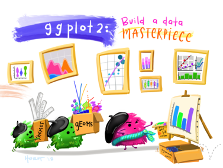

Building a masterpiece, by Allison Horst

## Gestalt Principles in Graphics

Gestalt (form or pattern) is a predictable way in which we organize sensory information.

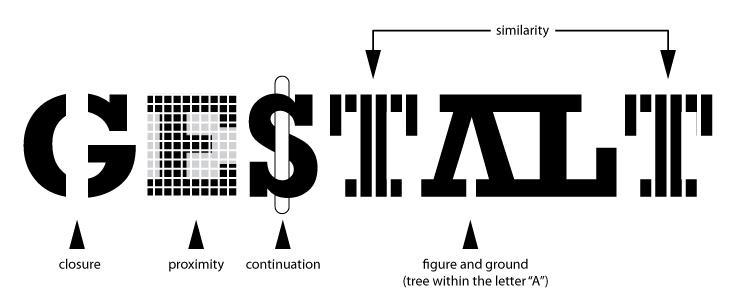

| Principle | Application in graphics |
| --- | --- |
| Enclosure | Facets |
| Connection | Lines |
| Proximity | Spacing and white space |
| Similarity | Color and shape |

## Testing Statistical Graphics

Evaluate design choices and understand cognitive biases through the use of visual tests.

Could ask participants to:

📊 identify differences in graphs.

📖 read information off of a chart accurately.

🌍 use data to make correct real-world decisions.

✏️ predict the next few observations.

## Task complexity

Carpenter and Shah (1988) identifies pattern recognition, interpretative processes, and integrative processes as strategies and processes required to complete tasks of varying degrees of complexity.

- **Pattern recognition** requires the viewer to encode graphic patterns.
- **Interpretive processes** operate on those patterns to construct meaning.
- **Integrative processes** then relate the meanings to the contextual scenario as inferred from labels and titles.

# Lineup Protocol (Buja et al. 2009)

## Introduction to Visual Inference

When doing exploratory data analysis, how do we know if what we see is actually there?

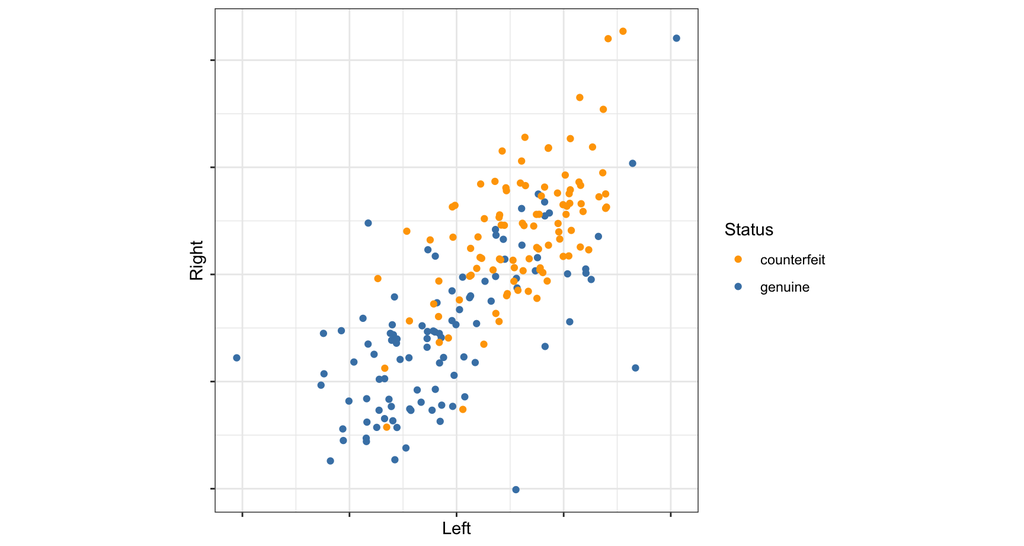

## Lineup Protocol (Buja et. al, 2009)

Embed a **target plot** (actual data) in a lineup of **null plots** (randomly permuted data sets).

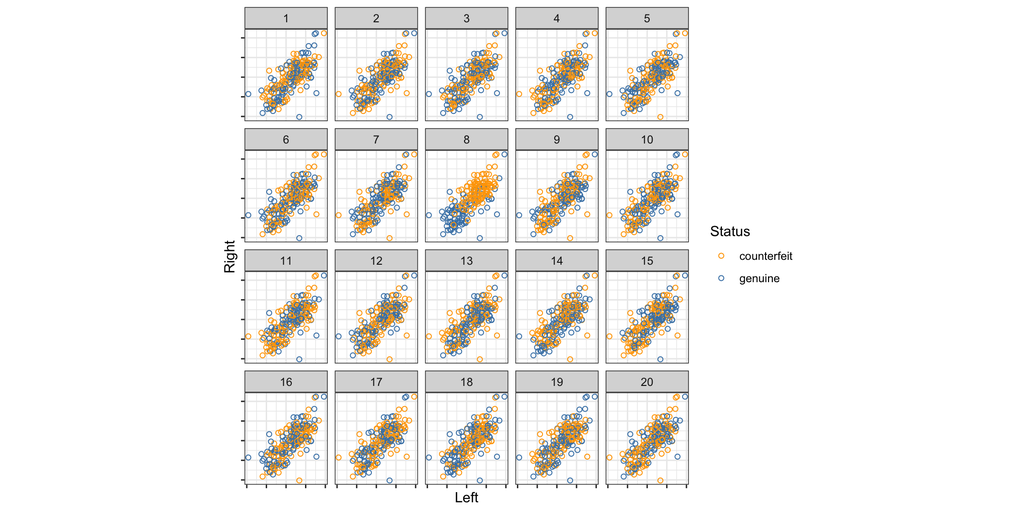

## Visual inference and numerical inference

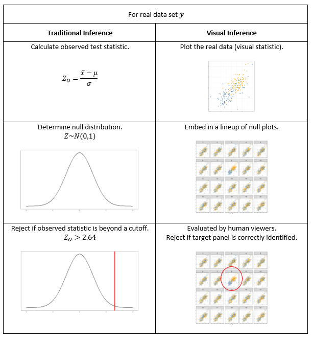

## Lineup Studies

- Statistical inference for exploratory data analysis and model diagnostics (Buja et al. 2009)
- Validation of Visual Statistical Inference, Applied to Linear Models (Majumder et al. 2013)
- Human Factors Influencing Visual Statistical Inference (Majumder et al. 2014)
- Variations of *Q*–*Q* Plots: The Power of Our Eyes! (Loy et al. 2016)
- Spatial Reasoning and Data Displays (VanderPlas and Hofmann 2015)
- [Clusters beat trend!? testing feature hierarchy in statistical graphics](https://www.tandfonline.com/doi/full/10.1080/10618600.2016.1209116?casa_token=ZTotcyTpAekAAAAA:0ZJcegDldgPo53zNw5581EKGYr5b2mtUj393V7v4OjIjhiOPN9MuiRjPdVrBvYzAoCGX3fbSpAMt5Bw) (VanderPlas and Hofmann 2017)
- Statistical Significance Calculations for Scenarios in Visual Inference (VanderPlas et al. 2021)
- [Clusters, Trends, and Choices: Feature Selection in Interactive Statistical Graphics](https://doi.org/10.6339/26-JDS1221) (Le et al. 2026)
- [Can You See The Change? Visual Perception in Change Point Analysis](https://doi.org/10.1080/10618600.2025.2485278) (Fudolig et al. 2025)

# “You Draw It” (Robinson et al. 2023)

## “You Draw It” for News Media

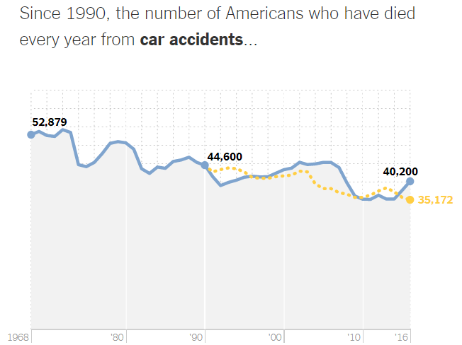

New York Times (Aisch et al. 2015)

## “You Draw It” for Graphical Testing

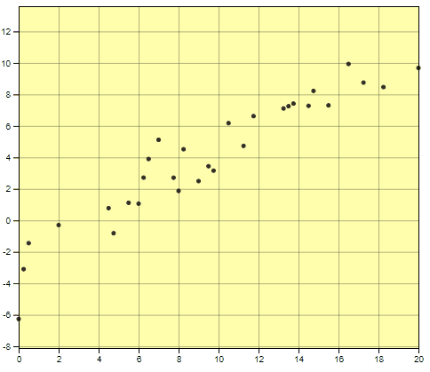

[Eye Fitting Straight Lines in the Modern Era](https://www.tandfonline.com/doi/abs/10.1080/10618600.2022.2140668) (Robinson et al. 2022)

[youdrawitR](https://alisa-krasilnikov.github.io/youdrawitR/) Package by Alisa Krasilnikov

# Perception of Logarithmic Scales

## Logarithmic Mapping

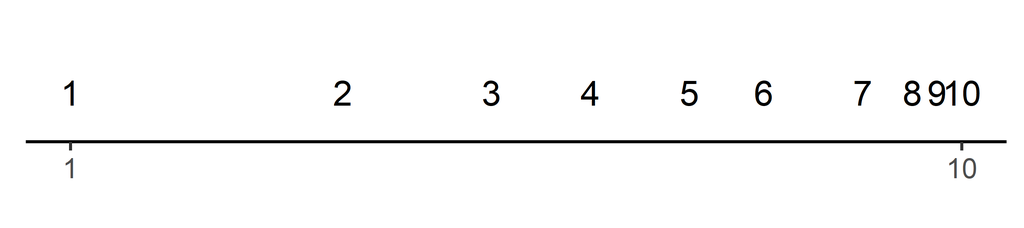

## Exponential Growth

Von Bergmann (2021)

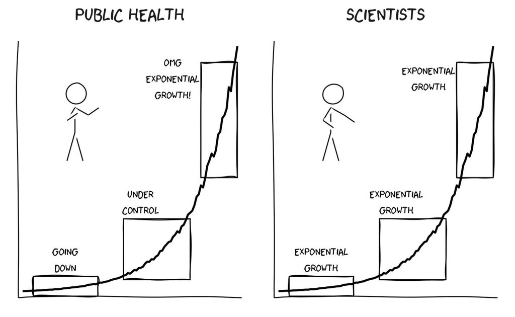

## Benefits and pitfalls of log scales

Burn-Murdoch et al. (2020)

[figure not shown]

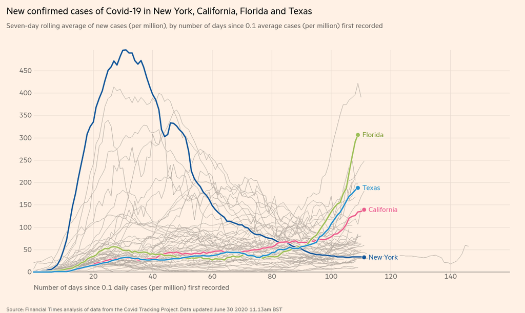

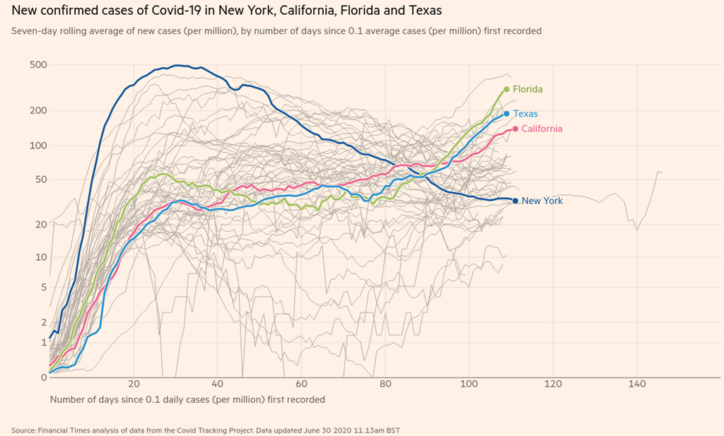

## Research objectives

**Big Idea:** Are there benefits to displaying exponentially increasing data on a log scale rather than a linear scale?

1. **Perception through Lineups** – tests an individual’s ability to perceptually differentiate exponentially increasing data with differing rates of change on both the linear and log scale.
2. **Prediction with ‘You Draw It’** – tests an individual’s ability to make predictions for exponentially increasing data.
3. **Estimation by Numerical Translation** – tests an individual’s ability to translate a graph of exponentially increasing data into real value quantities.

The series of graphical tests were conducted through an RShiny application found at https://emily-robinson.shinyapps.io/perception-of-statistical-graphics-log/.

## Lineup Experimental Task

### Linear scale

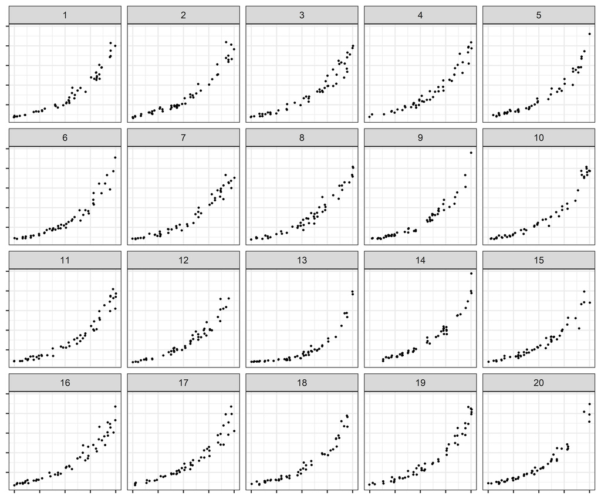

### Log scale

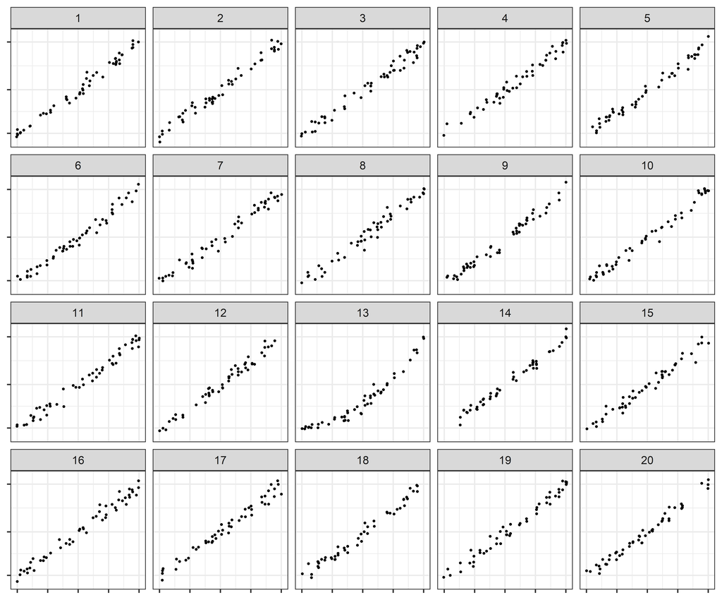

Outcome: successful identification of the target panel.

## Lineup Study Design and Generalized Linear Mixed Model

**Treatment design**

Three curvature levels resulting in six curvature combinations.

Two data replicates $\times$ two scales give 24 candidate lineups.

Each participant evaluates 12 lineups.

**Binary response GLMM**

$$\text{logit }P(Y_{ijk}) = \eta + \delta_i + \gamma_j + \delta \gamma_{ij} + s_l + d_k$$

Scale × curvature fixed effects.

Participant and simulated-data random intercepts.

## Lineup Results

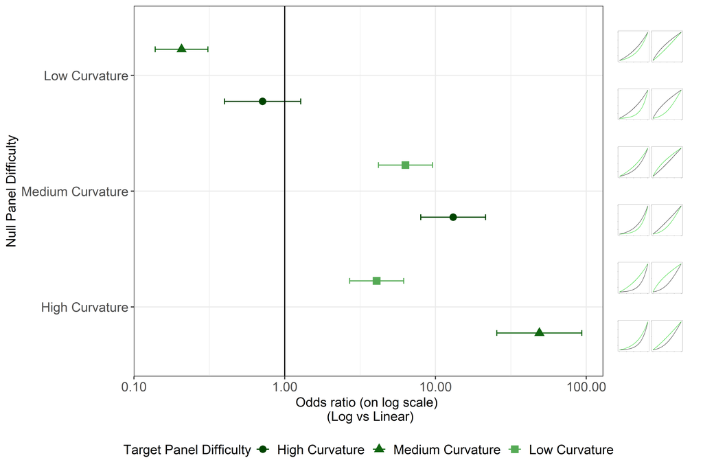

Neither scale has a uniform advantage across these comparisons.

## ‘You Draw It’ Experimental Task

*“Use your mouse to fill in the trend in the yellow box region.”*

The response is an entire drawn curve.

Compare participants’ visual forecasts with a statistically fitted reference curve.

(Robinson et al. 2022, 2023)

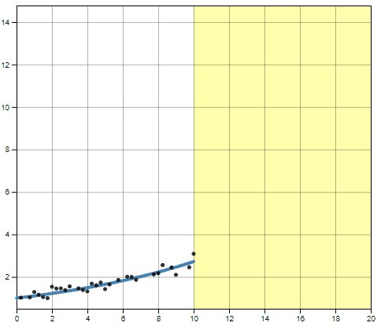

## ‘You Draw It’ Treatment Design

$y_i=e^{\beta x_i+e_i},\quad e_i\sim N(0,\sigma^2),\quad N=30$

2 $\times$ 2 $\times$ 2: growth rate $\times$ point truncation $\times$ display scale.

### Low growth · Linear

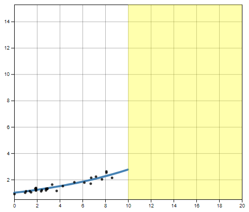

### High growth · Linear

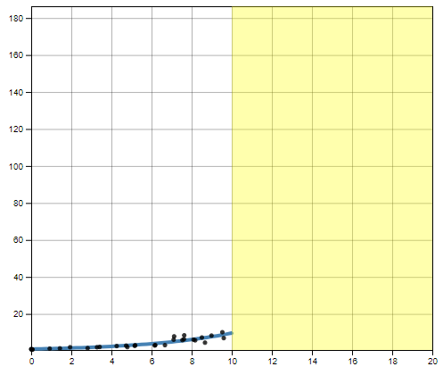

### Low growth · Log

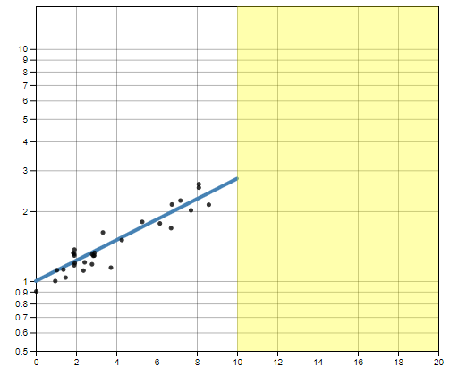

### High growth · Log

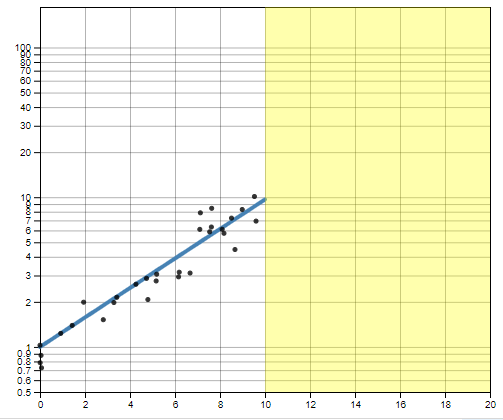

## ‘You Draw It’ Treatment Design (continued)

### Low growth · Linear

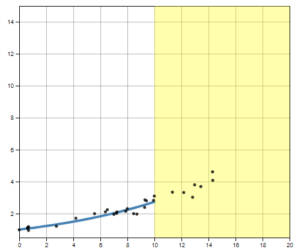

### High growth · Linear

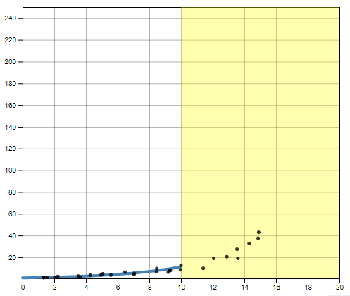

### Low growth · Log

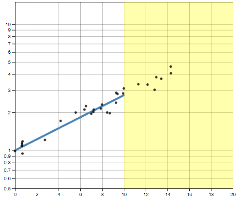

### High growth · Log

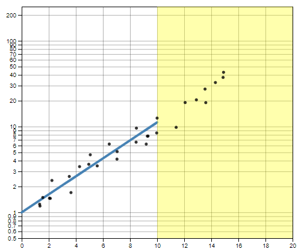

## Prediction Feedback Data

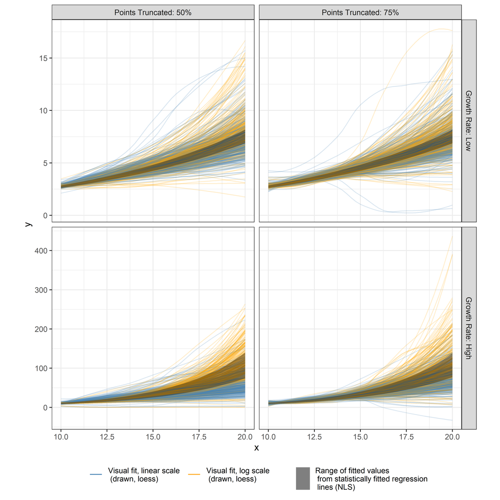

## Generalized Additive Mixed Model

Fit separately for each growth rate (low = 1, high = 2):

$$e_{1jklm,NLS}=\tau_{1jk}+s_{1jk}(x_{1jklm})+p_l+s_l(x_{1jklm})$$
$$e_{2jklm,NLS}=\tau_{2jk}+s_{2jk}(x_{2jklm})+p_l+s_l(x_{2jklm})$$

- $j$: point truncation, $k$: scale, $l$: participant, $m$: location.
- $\tau_{\cdot jk}$ and $s_{\cdot jk}$: treatment intercept and smoothing spline.
- $p_l\sim N(0,\sigma^2_\text{participant})$: participant random intercept.
- $s_l$: participant random smoothing spline.

## GAMM Results

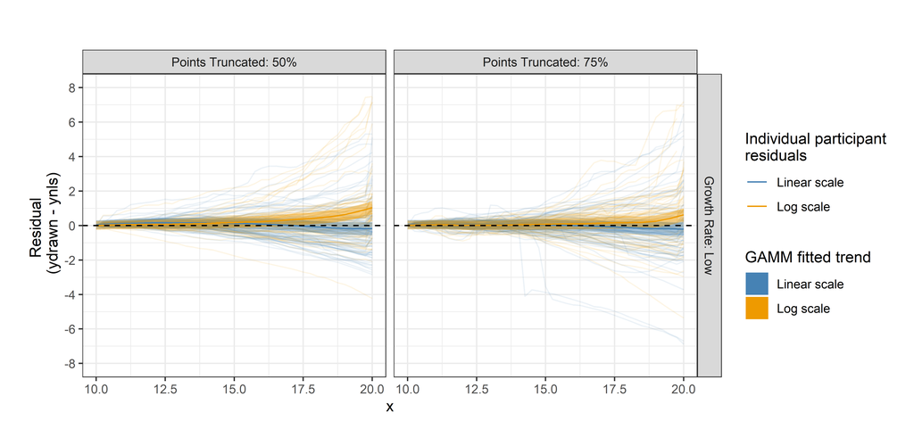

## GAMM Results (continued)

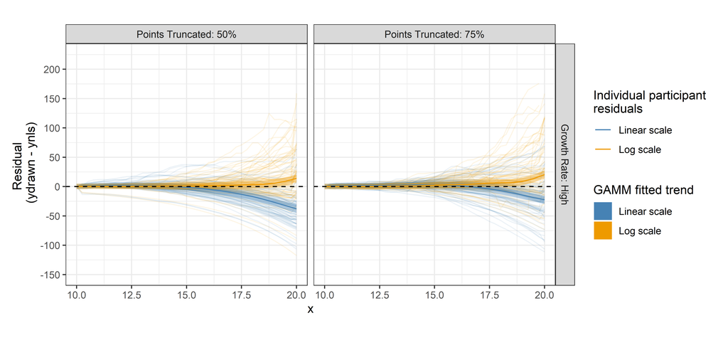

## Numerical Translation and Estimation: Data and Plot Generation

Two simulated data sets:

$$y_i=\alpha e^{\beta x_i+\epsilon_i}+\theta,$$
$$\epsilon_i\sim N(0,\sigma^2).$$

Fictional population scenarios: Ewoks and Tribbles.

The log display uses base 2.

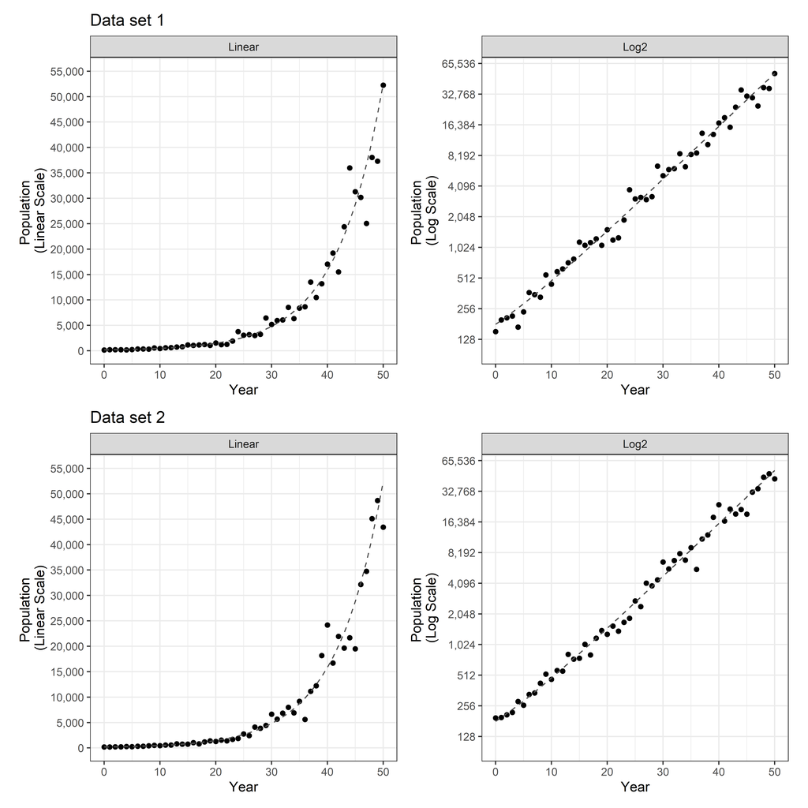

## Numerical Translation and Estimation: Questions

| Question | Required operation |
| --- | --- |
| Population in year 10 | Read a population value |
| Year population reaches 4,000 | Read a time value |
| Increase from year 20 to 40 | Subtract two population estimates |
| “How many times more” in 40 than 20 | Compare population estimates by a ratio |
| Time for year-10 population to double | Double a population estimate, then read time |

Calculator inputs and scratch work help identify participants’ strategies.

## Estimation of Population: Elementary Q1

*“What is the population in year 10?”*

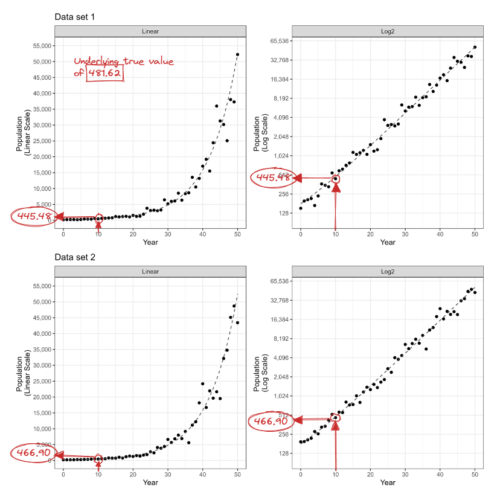

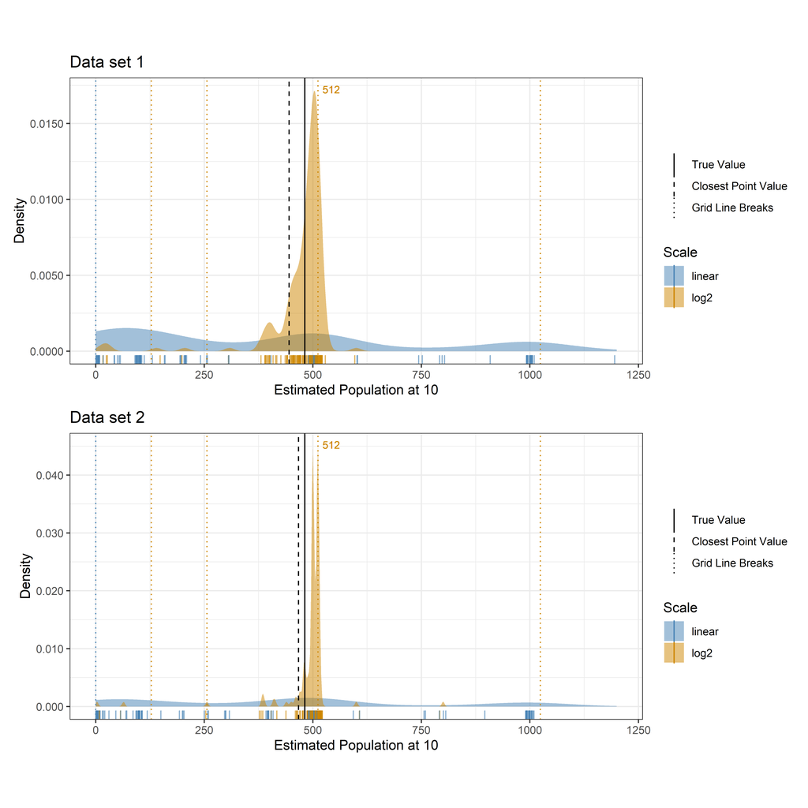

## Additive Increase in Population: Intermediate Q1

*“From 20 to 40, the population increases by ____ [creatures].”*

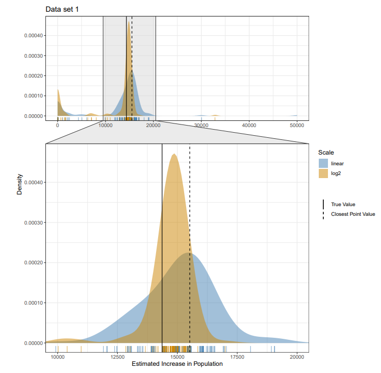